# Step 3: ATAC-Seq-Data-Analysis-QC on all cells

Step 3.2.2: Visualisation of ATAC-Seq-Data-Analysis-QC on all cells using seurat’s ‘LogNormalize’

Xenia Sirodzha

2025-02-11

As the workflow for ATAC-seq QC was established in part 1, I performed this workflow on the entire data set. However, performing pseudo-bulking and normalization and subsequent visualization with the data from all cells is very computationally intensive. Therefore, visualization was performed separately from the pseudo-bulking and normalization here.

# Libraries

These are the packages required for the code below.

```r
library(tidyverse)
library(binom)
library(lubridate)
library(broom)
library(scales) #for scale transformations
```

```r
library(cowplot) #arranging plots
library(ggpubr)
library(ggridges)
library(ggthemes) #stylising plots
library(ggplot2)
library(ggsci) #color palettes
library(readxl) #for loading excel files
library(Seurat) #for rna-seq data, atac-seq data
library(Signac) #for atac seq data
```

# 1 Data Loading

```r
readRDS("Data/Lin_2023_zfish_snATAC-seq/Cell-type_Peak_Matrix.rds") -> zfish_snATAC_seq_pk_mtrx
readRDS("Data/psd.bulk.zfish_atac.rds") -> psd.bulk.zfish_atac
```

# 2 Data wrangling for plotting

After normalisation, I prepared the data to plot with tidyverse. First, I converted the matrix to a data frame, then I calculated the values which will be plotted as well(sum of pk_counts, coefficient of variance (cv))

```r
as.data.frame(psd.bulk.zfish_atac@assays$atac$data)%>%
  pivot_longer(cols=!contains("rownames"), ,values_to = "pk_counts", names_to = "celltype") %>%
  mutate(pk_count_sum= sum(pk_counts)) %>%
  mutate(cv=sd(pk_counts) / mean(pk_counts)) %>%
  group_by(celltype) %>%
  mutate(pk_count_sum_celltype= sum(pk_counts)) %>%
  mutate(cv_celltype=sd(pk_counts) / mean(pk_counts)) %>%
  mutate(all="all celltypes")-> df_psd.bulk.zfish_atac

df_psd.bulk.zfish_atac
```

| celltype | pk_counts | pk_count_sum | cv | pk_count_sum_celltype | cv_celltype | all |
| --- | --- | --- | --- | --- | --- | --- |
| anterior/posterior axis | 0.0824221104 | 220551 | 1.443362 | 9633.527 | 1.322811 | all celltypes |
| blastomere | 0.0669937369 | 220551 | 1.443362 | 9490.692 | 1.685709 | all celltypes |
| central nervous system | 0.0609794375 | 220551 | 1.443362 | 9599.024 | 1.409107 | all celltypes |
| digestive system | 0.0640767665 | 220551 | 1.443362 | 9561.809 | 1.520324 | all celltypes |
| epiblast | 0.0550805734 | 220551 | 1.443362 | 9601.223 | 1.409904 | all celltypes |
| erythroid lineage cell | 0.0734343803 | 220551 | 1.443362 | 9515.157 | 1.633445 | all celltypes |
| EVL | 0.0548392519 | 220551 | 1.443362 | 9579.090 | 1.469806 | all celltypes |
| forebrain | 0.1022709653 | 220551 | 1.443362 | 9555.172 | 1.531403 | all celltypes |
| hypoblast | 0.0590472600 | 220551 | 1.443362 | 9597.549 | 1.420217 | all celltypes |
| immature eye | 0.1183300402 | 220551 | 1.443362 | 9568.495 | 1.496877 | all celltypes |

[output cut: 9990 more lines]

# 3 Plotting

Subsequently, the wrangled data was visualized analogous to the script in step 2 “02-06-ATAC-Seq-Analysis-Step-2.1 seurat norm”.

## 3.1 Distribution after pseudo-bulking by celltype

Then, the distribution of peaks overall and by celltype was visualized below.

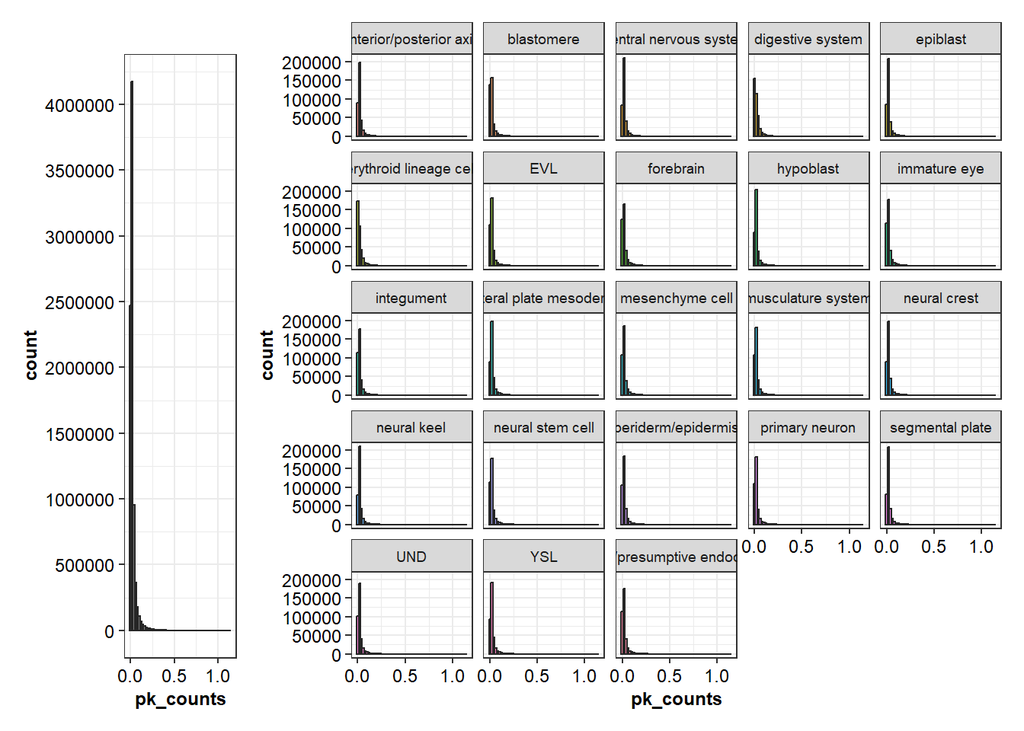

```r
# overall
df_psd.bulk.zfish_atac %>%
 ggplot(aes(x=pk_counts))+geom_histogram(binwidth = 0.02, color="gray15", alpha=0.8)+
 scale_y_continuous(breaks = scales::breaks_pretty(n=10))+
   scale_x_continuous(breaks = scales::breaks_pretty(n=4))+
  coord_fixed(ratio = 0.0000015)+
  theme_bw()+ theme(text = element_text(size = 9, family="sans", color="black"), #stylisation
        axis.text = element_text(size=9, color="black"),
        axis.title=element_text(size=9, face = "bold"),
        plot.subtitle=element_text(size=10.5),
        plot.title=element_text(size=11, face = "bold"),
        legend.position ="none") ->dis.counts.1

# by celltype
 ggplot(df_psd.bulk.zfish_atac, aes(x=pk_counts, fill = celltype))+
  geom_histogram(binwidth = 0.02, color="gray15", alpha=0.8)+
  scale_y_continuous(breaks = scales::breaks_pretty(n=5))+
   scale_x_continuous(breaks = scales::breaks_pretty(n=4))+
  facet_wrap(facets = "celltype")+
  theme_bw()+ theme(text = element_text(size = 9, family="sans", color="black"), #stylisation
        axis.text = element_text(size=9, color="black"),
        axis.title=element_text(size=9, face = "bold"),
        plot.subtitle=element_text(size=10.5),
        plot.title=element_text(size=11, face = "bold"),
        legend.position ="none") ->dis.counts.cell.1

 # display
dis.counts.1|dis.counts.cell.1
```

Overall, the counts are shifted towards zero and not normally distributed, indicating that seurat’s LogNormalize did not normalize the data sufficiently. This also applies to the distributions per cell type.

## 3.3 Sum of all peaks

The sum of all peaks is 220,551.

```r
unique(df_psd.bulk.zfish_atac$pk_count_sum)
```

```
## [1] 220551
```

This is 100 times less than with the manual method performed in “02-11-ATAC-Seq-Analysis-Step-3.1.1-log 1+x on all celltypes”.

Then, the sum of all peaks overall and by celltype was visualized below.

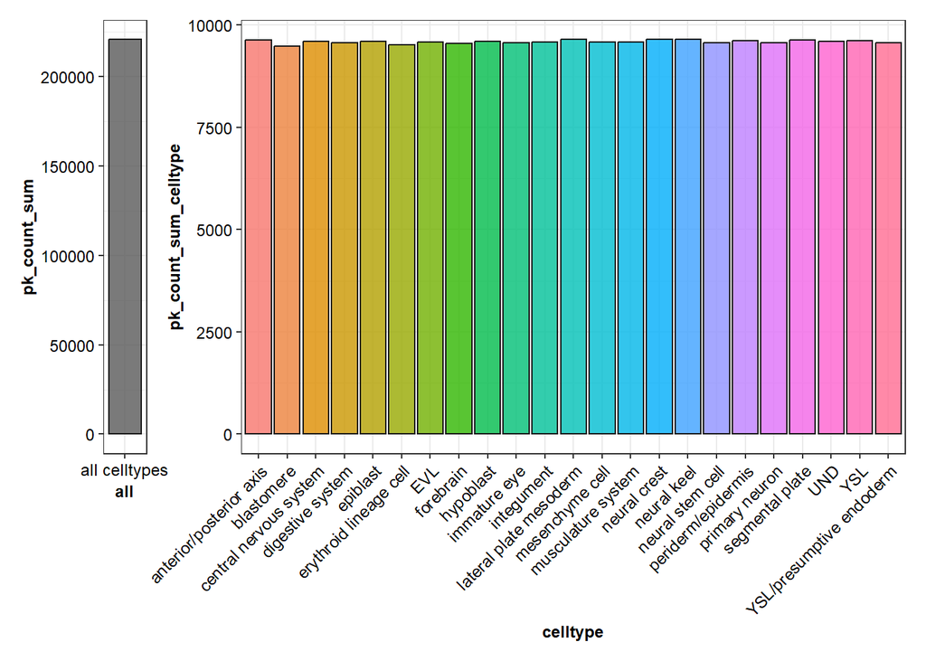

```r
df_psd.bulk.zfish_atac %>%
  ungroup() %>%
  distinct(all, pk_count_sum) %>%
  ggplot(aes(x=all, y=pk_count_sum))+
  geom_col(alpha=0.8, color="gray10")+
  coord_fixed(ratio = 0.00005)+
  theme_bw()+ theme(text = element_text(size = 9, family="sans", color="black"), #stylisation
        axis.text = element_text(size=9, color="black"),
        axis.title=element_text(size=9, face = "bold"),
        plot.subtitle=element_text(size=10.5),
        plot.title=element_text(size=11, face = "bold"),
        legend.position ="none") -> sum.peaks.all.1


df_psd.bulk.zfish_atac %>%
  group_by(celltype) %>%
  distinct(pk_count_sum_celltype, pk_count_sum) %>%
  ggplot(aes(x=celltype, y=pk_count_sum_celltype, fill=celltype))+
  geom_col(alpha=0.8, color="gray10")+
  theme_bw()+ theme(text = element_text(size = 9, family="sans", color="black"), #stylisation
        axis.text = element_text(size=9, color="black"),
        axis.title=element_text(size=9, face = "bold"),
        axis.text.x = element_text(angle = 45, hjust = 1),
        plot.subtitle=element_text(size=10.5),
        plot.title=element_text(size=11, face = "bold"),
        legend.position ="none") -> sum.peaks.celltype.1

sum.peaks.all.1|sum.peaks.celltype.1
```

The sum of all peaks per cell type is almost identical (9000). This indicated that the transformation performed by seurat’s “LogNormalize” does not preserve the underlying distribution of the values.

## 3.4 Coefficient of variation

Next, the coefficient of variation was displayed in a barplot.

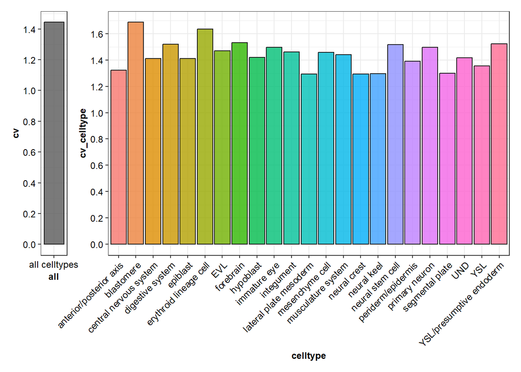

```r
df_psd.bulk.zfish_atac %>%
  ungroup() %>%
  distinct(all, cv) %>%
  ggplot(aes(x=all, y=cv ))+
  geom_col(alpha=0.8, color="gray10")+
  scale_y_continuous(n.breaks=10)+
  coord_fixed(ratio = 7)+
  theme_bw()+ theme(text = element_text(size = 9, family="sans", color="black"), #stylisation
        axis.text = element_text(size=9, color="black"),
        axis.title=element_text(size=9, face = "bold"),
        plot.subtitle=element_text(size=10.5),
        plot.title=element_text(size=11, face = "bold"),
        legend.position ="none") -> cv.all.1

df_psd.bulk.zfish_atac %>%
  group_by(celltype) %>%
  distinct(cv_celltype, cv) %>%
  ggplot(aes(x=celltype, y=cv_celltype, fill=celltype))+
  geom_col(alpha=0.8, color="gray10")+
  scale_y_continuous(n.breaks=10)+
  theme_bw()+ theme(text = element_text(size = 9, family="sans", color="black"), #stylisation
        axis.text = element_text(size=9, color="black"),
        axis.title=element_text(size=9, face = "bold"),
        axis.text.x = element_text(angle = 45, hjust = 1),
        plot.subtitle=element_text(size=10.5),
        plot.title=element_text(size=11, face = "bold"),
        legend.position ="none") ->cv.celltype.1

cv.all.1|cv.celltype.1
```

## 3.5 Count distribution by cell type

Then, the count distribution by cell type was plotted analogously to “02-11-ATAC-Seq-Analysis-Step-3.2.1-log 1+x on all celltypes”.

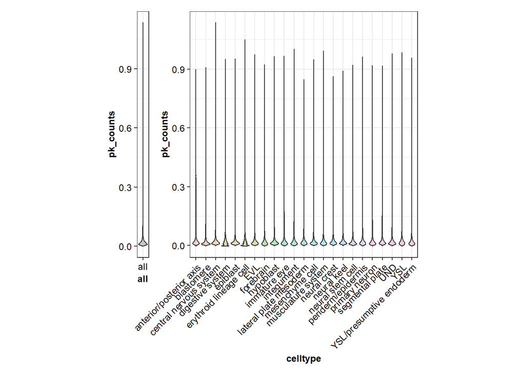

```r
df_psd.bulk.zfish_atac %>%
  mutate(all="all") %>%
 ggplot( aes( x=all, y=pk_counts))+
  geom_violin(color="grey20", alpha=0.3, fill="gray30", trim=F)+
  coord_fixed(ratio = 20)+
  theme_bw()+ theme(text = element_text(size = 4, family="sans", color="black"), #stylisation
        axis.text = element_text(size=9, color="black"),
        axis.title=element_text(size=9, face = "bold"),
        plot.subtitle=element_text(size=10.5),
        plot.title=element_text(size=11, face = "bold"),
        legend.position ="none") -> v.plot.all.1


 ggplot(df_psd.bulk.zfish_atac, aes(x=celltype, y=pk_counts, fill = celltype))+
  geom_violin(color="grey20", alpha=0.3, trim=F)+
   coord_equal(ratio = 20)+
  theme_bw()+ theme(text = element_text(size = 4, family="sans", color="black"), #stylisation
        axis.text = element_text(size=9, color="black"),
        axis.text.x = element_text(angle = 45, hjust = 1),
        axis.title=element_text(size=9, face = "bold"),
        plot.subtitle=element_text(size=10.5),
        plot.title=element_text(size=11, face = "bold"),
        legend.position ="none") -> v.plot.cells.1

 v.plot.all.1|v.plot.cells.1
```

The data is hardly visible so I made the following adjustments: boxplot and scale limits set to 0 and 0.1

The resulting plot can be seen down below.

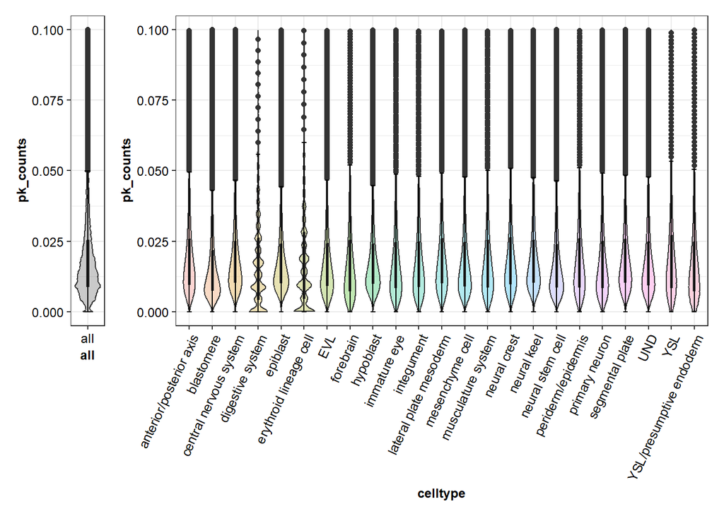

```r
df_psd.bulk.zfish_atac %>%
  mutate(all="all") %>%
 ggplot( aes( x=all, y=pk_counts))+
  geom_violin(color="grey20", alpha=0.3, fill="gray30", trim=F)+
  geom_boxplot(width = 0.07)+
  stat_boxplot(geom ='errorbar', width=0.2, position=position_dodge(0.5))+
  scale_y_continuous(limits = c(0,0.1))+
  coord_fixed(ratio = 100)+
  theme_bw()+ theme(text = element_text(size = 9, family="sans", color="black"), #stylisation
        axis.text = element_text(size=9, color="black"),
        axis.title=element_text(size=9, face = "bold"),
        plot.subtitle=element_text(size=10.5),
        plot.title=element_text(size=11, face = "bold"),
        legend.position ="none") -> v.plot.all.box.1


 ggplot(df_psd.bulk.zfish_atac, aes(x=celltype, y=pk_counts, fill = celltype))+
  geom_violin(color="grey20", alpha=0.3, trim=F)+
   geom_boxplot(width = 0.07)+
  stat_boxplot(geom ='errorbar', width=0.2, position=position_dodge(0.5))+
   scale_y_continuous(limits = c(0,0.1))+
  # coord_equal(ratio = 20)+
   #facet_wrap(facets=vars(celltype), scales="free_x")+
  theme_bw()+ theme(text = element_text(size = 9, family="sans", color="black"), #stylisation
        axis.text = element_text(size=9, color="black"),
        #axis.text.x = element_blank(),
        axis.text.x = element_text(angle = 65, hjust = 1),
        axis.title=element_text(size=9, face = "bold"),
        plot.subtitle=element_text(size=10.5),
        plot.title=element_text(size=11, face = "bold"),
        legend.position ="none") -> v.plot.cells.box.1

 v.plot.all.box.1|v.plot.cells.box.1
```

Overall, digestive system cells and erythroid lineage cells are the only cell types, which are not normally distributed. This was also the case in “02-11-ATAC-Seq-Analysis-Step-3.2.1-log 1+x on all celltypes”. However, the count values all center around 0.01 be it per cell type or overall. Therefore, the data points were not effectively normalized by seurat’s “LogNormalize”. For that reason, only manual normalization should be used for further analysis and for assessing the quality of the data set.